# Project: Identify Customer Segments

In this project, you will apply unsupervised learning techniques to identify segments of the population that form the core customer base for a mail-order sales company in Germany. These segments can then be used to direct marketing campaigns towards audiences that will have the highest expected rate of returns. The data that you will use has been provided by our partners at Bertelsmann Arvato Analytics, and represents a real-life data science task.

This notebook will help you complete this task by providing a framework within which you will perform your analysis steps. In each step of the project, you will see some text describing the subtask that you will perform, followed by one or more code cells for you to complete your work. **Feel free to add additional code and markdown cells as you go along so that you can explore everything in precise chunks.** The code cells provided in the base template will outline only the major tasks, and will usually not be enough to cover all of the minor tasks that comprise it.

It should be noted that while there will be precise guidelines on how you should handle certain tasks in the project, there will also be places where an exact specification is not provided. **There will be times in the project where you will need to make and justify your own decisions on how to treat the data.** These are places where there may not be only one way to handle the data. In real-life tasks, there may be many valid ways to approach an analysis task. One of the most important things you can do is clearly document your approach so that other scientists can understand the decisions you've made.

At the end of most sections, there will be a Markdown cell labeled **Discussion**. In these cells, you will report your findings for the completed section, as well as document the decisions that you made in your approach to each subtask. **Your project will be evaluated not just on the code used to complete the tasks outlined, but also your communication about your observations and conclusions at each stage.**

```python
# import libraries here; add more as necessary
import numpy as np
import pandas as pd
import matplotlib.pyplot as plt
import seaborn as sns
from seaborn import countplot
from sklearn.preprocessing import Imputer
from sklearn.preprocessing import LabelEncoder
from sklearn.cluster import KMeans

# magic word for producing visualizations in notebook
%matplotlib inline

'''
Import note: The classroom currently uses sklearn version 0.19.
If you need to use an imputer, it is available in sklearn.preprocessing.Imputer,
instead of sklearn.impute as in newer versions of sklearn.
'''
```

```
'\nImport note: The classroom currently uses sklearn version 0.19.\nIf you need to use an imputer, it is available in sklearn.preprocessing.Imputer,\ninstead of sklearn.impute as in newer versions of sklearn.\n'
```

### Step 0: Load the Data

Each row of the demographics files represents a single person, but also includes information outside of individuals, including information about their household, building, and neighborhood. You will use this information to cluster the general population into groups with similar demographic properties. Then, you will see how the people in the customers dataset fit into those created clusters. The hope here is that certain clusters are over-represented in the customers data, as compared to the general population; those over-represented clusters will be assumed to be part of the core userbase. This information can then be used for further applications, such as targeting for a marketing campaign.

To start off with, load in the demographics data for the general population into a pandas DataFrame, and do the same for the feature attributes summary. Note for all of the `.csv` data files in this project: they're semicolon (`;`) delimited, so you'll need an additional argument in your [`read_csv()`](https://pandas.pydata.org/pandas-docs/stable/generated/pandas.read_csv.html) call to read in the data properly. Also, considering the size of the main dataset, it may take some time for it to load completely.

Once the dataset is loaded, it's recommended that you take a little bit of time just browsing the general structure of the dataset and feature summary file. You'll be getting deep into the innards of the cleaning in the first major step of the project, so gaining some general familiarity can help you get your bearings.

```python
# Load in the general demographics data.
azdias = pd.read_csv('./Udacity_AZDIAS_Subset.csv', sep=';')

# Load in the feature summary file.
feat_info = pd.read_csv('./AZDIAS_Feature_Summary.csv', sep=';')
```

```python
# Check the structure of the data after it's loaded (e.g. print the number of
# rows and columns, print the first few rows).
azdias.shape
# azdias.shape[1]
```

```
(891221, 85)
```

```python
azdias.head(10)
```

|  | AGER_TYP | ALTERSKATEGORIE_GROB | ANREDE_KZ | CJT_GESAMTTYP | FINANZ_MINIMALIST | FINANZ_SPARER | FINANZ_VORSORGER | FINANZ_ANLEGER | FINANZ_UNAUFFAELLIGER | FINANZ_HAUSBAUER | ... | PLZ8_ANTG1 | PLZ8_ANTG2 | PLZ8_ANTG3 | PLZ8_ANTG4 | PLZ8_BAUMAX | PLZ8_HHZ | PLZ8_GBZ | ARBEIT | ORTSGR_KLS9 | RELAT_AB |
| --- | --- | --- | --- | --- | --- | --- | --- | --- | --- | --- | --- | --- | --- | --- | --- | --- | --- | --- | --- | --- | --- |
| 0 | -1 | 2 | 1 | 2.0 | 3 | 4 | 3 | 5 | 5 | 3 | ... | NaN | NaN | NaN | NaN | NaN | NaN | NaN | NaN | NaN | NaN |
| 1 | -1 | 1 | 2 | 5.0 | 1 | 5 | 2 | 5 | 4 | 5 | ... | 2.0 | 3.0 | 2.0 | 1.0 | 1.0 | 5.0 | 4.0 | 3.0 | 5.0 | 4.0 |
| 2 | -1 | 3 | 2 | 3.0 | 1 | 4 | 1 | 2 | 3 | 5 | ... | 3.0 | 3.0 | 1.0 | 0.0 | 1.0 | 4.0 | 4.0 | 3.0 | 5.0 | 2.0 |
| 3 | 2 | 4 | 2 | 2.0 | 4 | 2 | 5 | 2 | 1 | 2 | ... | 2.0 | 2.0 | 2.0 | 0.0 | 1.0 | 3.0 | 4.0 | 2.0 | 3.0 | 3.0 |
| 4 | -1 | 3 | 1 | 5.0 | 4 | 3 | 4 | 1 | 3 | 2 | ... | 2.0 | 4.0 | 2.0 | 1.0 | 2.0 | 3.0 | 3.0 | 4.0 | 6.0 | 5.0 |
| 5 | 3 | 1 | 2 | 2.0 | 3 | 1 | 5 | 2 | 2 | 5 | ... | 2.0 | 3.0 | 1.0 | 1.0 | 1.0 | 5.0 | 5.0 | 2.0 | 3.0 | 3.0 |
| 6 | -1 | 2 | 2 | 5.0 | 1 | 5 | 1 | 5 | 4 | 3 | ... | 3.0 | 3.0 | 1.0 | 0.0 | 1.0 | 5.0 | 5.0 | 4.0 | 6.0 | 3.0 |
| 7 | -1 | 1 | 1 | 3.0 | 3 | 3 | 4 | 1 | 3 | 2 | ... | 3.0 | 3.0 | 1.0 | 0.0 | 1.0 | 4.0 | 4.0 | 2.0 | 5.0 | 2.0 |
| 8 | -1 | 3 | 1 | 3.0 | 4 | 4 | 2 | 4 | 2 | 2 | ... | 2.0 | 3.0 | 2.0 | 1.0 | 1.0 | 3.0 | 3.0 | 2.0 | 4.0 | 3.0 |
| 9 | -1 | 3 | 2 | 4.0 | 2 | 4 | 2 | 3 | 5 | 4 | ... | 2.0 | 3.0 | 2.0 | 1.0 | 1.0 | 3.0 | 3.0 | 2.0 | 3.0 | 1.0 |

10 rows × 85 columns

```python
feat_info.head()
```

|  | attribute | information_level | type | missing_or_unknown |
| --- | --- | --- | --- | --- |
| 0 | AGER_TYP | person | categorical | [-1,0] |
| 1 | ALTERSKATEGORIE_GROB | person | ordinal | [-1,0,9] |
| 2 | ANREDE_KZ | person | categorical | [-1,0] |
| 3 | CJT_GESAMTTYP | person | categorical | [0] |
| 4 | FINANZ_MINIMALIST | person | ordinal | [-1] |

> **Tip**: Add additional cells to keep everything in reasonably-sized chunks! Keyboard shortcut `esc --> a` (press escape to enter command mode, then press the 'A' key) adds a new cell before the active cell, and `esc --> b` adds a new cell after the active cell. If you need to convert an active cell to a markdown cell, use `esc --> m` and to convert to a code cell, use `esc --> y`.

## Step 1: Preprocessing

### Step 1.1: Assess Missing Data

The feature summary file contains a summary of properties for each demographics data column. You will use this file to help you make cleaning decisions during this stage of the project. First of all, you should assess the demographics data in terms of missing data. Pay attention to the following points as you perform your analysis, and take notes on what you observe. Make sure that you fill in the **Discussion** cell with your findings and decisions at the end of each step that has one!

#### Step 1.1.1: Convert Missing Value Codes to NaNs

The fourth column of the feature attributes summary (loaded in above as `feat_info`) documents the codes from the data dictionary that indicate missing or unknown data. While the file encodes this as a list (e.g. `[-1,0]`), this will get read in as a string object. You'll need to do a little bit of parsing to make use of it to identify and clean the data. Convert data that matches a 'missing' or 'unknown' value code into a numpy NaN value. You might want to see how much data takes on a 'missing' or 'unknown' code, and how much data is naturally missing, as a point of interest.

**As one more reminder, you are encouraged to add additional cells to break up your analysis into manageable chunks.**

```python
# Identify missing or unknown data values and convert them to NaNs.

i = 0 # i is the row index of feat_info

'''
for column in azdias.columns:
    missing_or_unknown = feat_info.iat[i,3][1:-1]
    mou = missing_or_unknown.split(',')
    print(mou)

    for row in azdias.index:
        if azdias.loc[row, column] == int(mou[0]):
            print(azdias.loc[row, column])
            azdias.loc[row, column] = np.NaN
            print(azdias.loc[row, column])

'''
for column in azdias.columns:

    if feat_info.iat[i,3] == '[]':
        mou = []
    else:
        # deal with the missing_or_unknown list, append the float type to the list
        missing_or_unknown = feat_info.iat[i,3][1:-1]
        mou = missing_or_unknown.split(',')
        for ii in range(len(mou)):
            if mou[ii] not in ['X', 'XX']:
                mou.append(str(float(int(mou[ii]))))
       # mou = list(map(int, mou))

    azdias.loc[:, column].mask(azdias.loc[:, column].astype('str').isin(mou), inplace=True)

    i += 1
```

```python
azdias.head()
```

|  | AGER_TYP | ALTERSKATEGORIE_GROB | ANREDE_KZ | CJT_GESAMTTYP | FINANZ_MINIMALIST | FINANZ_SPARER | FINANZ_VORSORGER | FINANZ_ANLEGER | FINANZ_UNAUFFAELLIGER | FINANZ_HAUSBAUER | ... | PLZ8_ANTG1 | PLZ8_ANTG2 | PLZ8_ANTG3 | PLZ8_ANTG4 | PLZ8_BAUMAX | PLZ8_HHZ | PLZ8_GBZ | ARBEIT | ORTSGR_KLS9 | RELAT_AB |
| --- | --- | --- | --- | --- | --- | --- | --- | --- | --- | --- | --- | --- | --- | --- | --- | --- | --- | --- | --- | --- | --- |
| 0 | NaN | 2.0 | 1 | 2.0 | 3 | 4 | 3 | 5 | 5 | 3 | ... | NaN | NaN | NaN | NaN | NaN | NaN | NaN | NaN | NaN | NaN |
| 1 | NaN | 1.0 | 2 | 5.0 | 1 | 5 | 2 | 5 | 4 | 5 | ... | 2.0 | 3.0 | 2.0 | 1.0 | 1.0 | 5.0 | 4.0 | 3.0 | 5.0 | 4.0 |
| 2 | NaN | 3.0 | 2 | 3.0 | 1 | 4 | 1 | 2 | 3 | 5 | ... | 3.0 | 3.0 | 1.0 | 0.0 | 1.0 | 4.0 | 4.0 | 3.0 | 5.0 | 2.0 |
| 3 | 2.0 | 4.0 | 2 | 2.0 | 4 | 2 | 5 | 2 | 1 | 2 | ... | 2.0 | 2.0 | 2.0 | 0.0 | 1.0 | 3.0 | 4.0 | 2.0 | 3.0 | 3.0 |
| 4 | NaN | 3.0 | 1 | 5.0 | 4 | 3 | 4 | 1 | 3 | 2 | ... | 2.0 | 4.0 | 2.0 | 1.0 | 2.0 | 3.0 | 3.0 | 4.0 | 6.0 | 5.0 |

5 rows × 85 columns

```python
azdias_111 = azdias.copy()
```

#### Step 1.1.2: Assess Missing Data in Each Column

How much missing data is present in each column? There are a few columns that are outliers in terms of the proportion of values that are missing. You will want to use matplotlib's [`hist()`](https://matplotlib.org/api/_as_gen/matplotlib.pyplot.hist.html) function to visualize the distribution of missing value counts to find these columns. Identify and document these columns. While some of these columns might have justifications for keeping or re-encoding the data, for this project you should just remove them from the dataframe. (Feel free to make remarks about these outlier columns in the discussion, however!)

For the remaining features, are there any patterns in which columns have, or share, missing data?

```python
# Perform an assessment of how much missing data there is in each column of the
# dataset.
NaN_column = azdias.isna().sum() # azdias.isnull().sum()
```

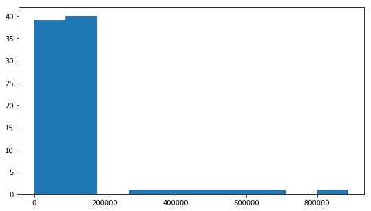

```python
# Investigate patterns in the amount of missing data in each column.
plt.figure(figsize=(9,5))
plt.hist(NaN_column)
# ax = plt.hist(NaN_column)
```

[output not shown]

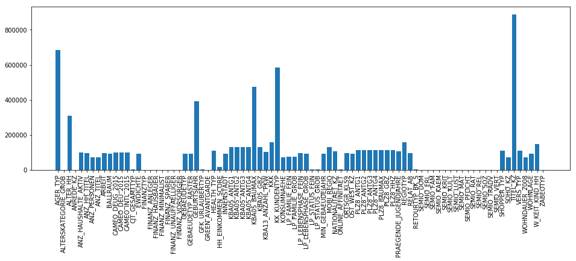

```python
# Remove the outlier columns from the dataset. (You'll perform other data
# engineering tasks such as re-encoding and imputation later.)
plt.figure(figsize=(16,5))
plt.xticks(rotation=90)
plt.bar(list(feat_info['attribute']), NaN_column)
```

```python
drop_columns = NaN_column[NaN_column > 177812]
drop_columns.index
```

```
Index(['AGER_TYP', 'GEBURTSJAHR', 'TITEL_KZ', 'ALTER_HH', 'KK_KUNDENTYP',
       'KBA05_BAUMAX'],
      dtype='object')
```

```python
azdias_dropColumns = azdias.drop(drop_columns.index, axis=1)
# azdias_dropColumns
```

#### Discussion 1.1.2: Assess Missing Data in Each Column

(Double click this cell and replace this text with your own text, reporting your observations regarding the amount of missing data in each column. Are there any patterns in missing values? Which columns were removed from the dataset?)

A: yes, six columns are outliers. The six 'AGER_TYP', 'GEBURTSJAHR', 'TITEL_KZ', 'ALTER_HH', 'KK_KUNDENTYP', 'KBA05_BAUMAX' were removed from the dataset.

#### Step 1.1.3: Assess Missing Data in Each Row

Now, you'll perform a similar assessment for the rows of the dataset. How much data is missing in each row? As with the columns, you should see some groups of points that have a very different numbers of missing values. Divide the data into two subsets: one for data points that are above some threshold for missing values, and a second subset for points below that threshold.

In order to know what to do with the outlier rows, we should see if the distribution of data values on columns that are not missing data (or are missing very little data) are similar or different between the two groups. Select at least five of these columns and compare the distribution of values.

- You can use seaborn's [`countplot()`](https://seaborn.pydata.org/generated/seaborn.countplot.html) function to create a bar chart of code frequencies and matplotlib's [`subplot()`](https://matplotlib.org/api/_as_gen/matplotlib.pyplot.subplot.html) function to put bar charts for the two subplots side by side.
- To reduce repeated code, you might want to write a function that can perform this comparison, taking as one of its arguments a column to be compared.

Depending on what you observe in your comparison, this will have implications on how you approach your conclusions later in the analysis. If the distributions of non-missing features look similar between the data with many missing values and the data with few or no missing values, then we could argue that simply dropping those points from the analysis won't present a major issue. On the other hand, if the data with many missing values looks very different from the data with few or no missing values, then we should make a note on those data as special. We'll revisit these data later on. **Either way, you should continue your analysis for now using just the subset of the data with few or no missing values.**

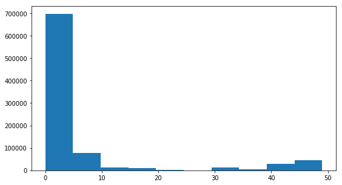

```python
# How much data is missing in each row of the dataset?
NaN_row = azdias_dropColumns.isna().sum(axis=1)

# Display the missing data distribution
plt.figure(figsize=(9,5))
plt.hist(NaN_row)
```

```python
# Write code to divide the data into two subsets based on the number of missing
# values in each row.

# Choose 10 as the thresshold number to do the seperate
subset_good = azdias_dropColumns[NaN_row <= 10]
subset_bad = azdias_dropColumns[NaN_row > 10]
# Preserve the index of good row for the using later
good_rows = subset_good.index
```

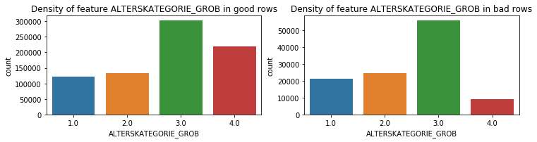

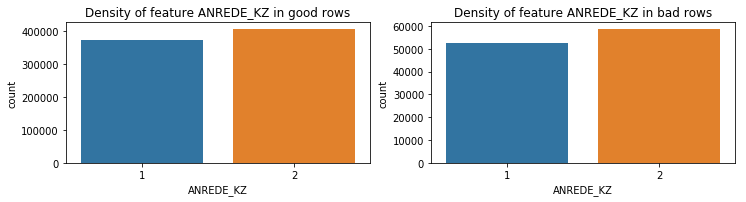

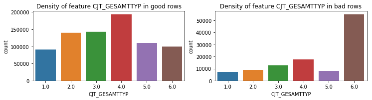

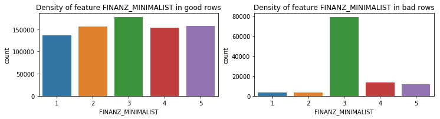

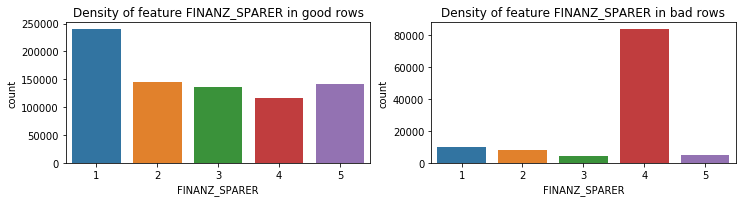

```python
# Compare the distribution of values for at least five columns where there are
# no or few missing values, between the two subsets.

for n, column in zip(range(5), azdias_dropColumns.items()):
    plt.figure(figsize=(12,15))
    ax1 = plt.subplot(5, 2 ,1)
    countplot(subset_good[column[0]])
    ax1.set_title("Density of feature %s in good rows" % column[0])
    ax2 = plt.subplot(5, 2, 2)
    countplot(subset_bad[column[0]])
    ax2.set_title("Density of feature %s in bad rows" % column[0])
```

#### Discussion 1.1.3: Assess Missing Data in Each Row

(Double-click this cell and replace this text with your own text, reporting your observations regarding missing data in rows. Are the data with lots of missing values are qualitatively different from data with few or no missing values?)

A: the data with lots of missing values seems to be more extreme on the pattern. Generally they are not quite the same at the distribution.

### Step 1.2: Select and Re-Encode Features

Checking for missing data isn't the only way in which you can prepare a dataset for analysis. Since the unsupervised learning techniques to be used will only work on data that is encoded numerically, you need to make a few encoding changes or additional assumptions to be able to make progress. In addition, while almost all of the values in the dataset are encoded using numbers, not all of them represent numeric values. Check the third column of the feature summary (`feat_info`) for a summary of types of measurement.

- For numeric and interval data, these features can be kept without changes.
- Most of the variables in the dataset are ordinal in nature. While ordinal values may technically be non-linear in spacing, make the simplifying assumption that the ordinal variables can be treated as being interval in nature (that is, kept without any changes).
- Special handling may be necessary for the remaining two variable types: categorical, and 'mixed'.

In the first two parts of this sub-step, you will perform an investigation of the categorical and mixed-type features and make a decision on each of them, whether you will keep, drop, or re-encode each. Then, in the last part, you will create a new data frame with only the selected and engineered columns.

Data wrangling is often the trickiest part of the data analysis process, and there's a lot of it to be done here. But stick with it: once you're done with this step, you'll be ready to get to the machine learning parts of the project!

```python
feat_info['type'].value_counts()
```

```
ordinal        49
categorical    21
numeric         7
mixed           7
interval        1
Name: type, dtype: int64
```

#### Step 1.2.1: Re-Encode Categorical Features

For categorical data, you would ordinarily need to encode the levels as dummy variables. Depending on the number of categories, perform one of the following:

- For binary (two-level) categoricals that take numeric values, you can keep them without needing to do anything.
- There is one binary variable that takes on non-numeric values. For this one, you need to re-encode the values as numbers or create a dummy variable.
- For multi-level categoricals (three or more values), you can choose to encode the values using multiple dummy variables (e.g. via [OneHotEncoder](http://scikit-learn.org/stable/modules/generated/sklearn.preprocessing.OneHotEncoder.html)), or (to keep things straightforward) just drop them from the analysis. As always, document your choices in the Discussion section.

```python
# Access categorical variables: which are binary, which are multi-level, and which one needs to be re-encoded?
feat_cat = feat_info.loc[feat_info['type'] == 'categorical', :]
```

```python
for index, content in feat_cat.iterrows():
    print('azdias column %s value counts:' % content['attribute'])
    print(azdias[content['attribute']].value_counts())
    print('\n')
```

```
azdias column AGER_TYP value counts:
2.0    98472
1.0    79802
3.0    27104
Name: AGER_TYP, dtype: int64


azdias column ANREDE_KZ value counts:
2    465305
1    425916
Name: ANREDE_KZ, dtype: int64


azdias column CJT_GESAMTTYP value counts:
4.0    210963
3.0    156449
6.0    153915
2.0    148795
5.0    117376
1.0     98869
Name: CJT_GESAMTTYP, dtype: int64


azdias column FINANZTYP value counts:
6    290367
1    199572
4    130625
2    110867
5    106436
3     53354
Name: FINANZTYP, dtype: int64


azdias column GFK_URLAUBERTYP value counts:
12.0    138545
5.0     120126
10.0    109127
8.0      88042
11.0     79740
4.0      63770
```

[output cut: 179 more lines]

```
4D     8570
3B     7160
6A     6810
9E     6379
6D     6073
6F     5392
7D     5333
4E     5321
1E     5065
7E     4633
1C     4317
5F     4283
1B     4071
5E     3581
Name: CAMEO_DEU_2015, dtype: int64
```

```python
# Re-encode categorical variable(s) to be kept in the analysis.

# The column "OST_WEST_KZ" and "CAMEO_DEU_2015" should be encoded

labelEnc = LabelEncoder()
# Preprocessing the Nan values, or the Encoder could not be imposed on
azdias_dropColumns['OST_WEST_KZ'].fillna('Na', inplace=True)
azdias_dropColumns['OST_WEST_KZ'] = labelEnc.fit_transform(azdias_dropColumns['OST_WEST_KZ'])
azdias_dropColumns['OST_WEST_KZ'].value_counts()
```

```
2    629528
1    168545
0     93148
Name: OST_WEST_KZ, dtype: int64
```

```python
azdias_dropColumns['CAMEO_DEU_2015'].fillna('Na', inplace=True)
azdias_dropColumns['CAMEO_DEU_2015'] = labelEnc.fit_transform(azdias_dropColumns['CAMEO_DEU_2015'])
azdias_dropColumns['CAMEO_DEU_2015'].value_counts()
```

```
44    99352
25    56672
35    52438
15    47819
8     35074
11    34769
30    34399
12    34307
36    33434
13    33155
37    30993
42    28593
40    27676
41    24987
31    24503
```

[output cut: 31 more lines]

#### Discussion 1.2.1: Re-Encode Categorical Features

(Double-click this cell and replace this text with your own text, reporting your findings and decisions regarding categorical features. Which ones did you keep, which did you drop, and what engineering steps did you perform?)

A: I've tried to use OneHotEncoder to encode the values, but it could not impose on the string as the Examples in the sklearn User Guide. Then I have to use LabelEncoder. I haven't dropped anything and also kept the Nans, encoded the Nans to a numeric value along with other values.

#### Step 1.2.2: Engineer Mixed-Type Features

There are a handful of features that are marked as "mixed" in the feature summary that require special treatment in order to be included in the analysis. There are two in particular that deserve attention; the handling of the rest are up to your own choices:

- "PRAEGENDE_JUGENDJAHRE" combines information on three dimensions: generation by decade, movement (mainstream vs. avantgarde), and nation (east vs. west). While there aren't enough levels to disentangle east from west, you should create two new variables to capture the other two dimensions: an interval-type variable for decade, and a binary variable for movement.
- "CAMEO_INTL_2015" combines information on two axes: wealth and life stage. Break up the two-digit codes by their 'tens'-place and 'ones'-place digits into two new ordinal variables (which, for the purposes of this project, is equivalent to just treating them as their raw numeric values).
- If you decide to keep or engineer new features around the other mixed-type features, make sure you note your steps in the Discussion section.

Be sure to check `Data_Dictionary.md` for the details needed to finish these tasks.

```python
# Investigate "PRAEGENDE_JUGENDJAHRE" and engineer two new variables.
PRAEGENDE_JUGENDJAHRE = azdias_dropColumns['PRAEGENDE_JUGENDJAHRE']

# Handle the decade
decade = []

for item in PRAEGENDE_JUGENDJAHRE:
    if item in [1, 2]:
        decade.append(1)
    elif item in [3, 4]:
        decade.append(2)
    elif item in [5, 6, 7]:
        decade.append(3)
    elif item in [8, 9]:
        decade.append(4)
    elif item in [10, 11, 12, 13]:
        decade.append(5)
    elif item in [14, 15]:
        decade.append(6)
    else:
        decade.append(np.NaN)

azdias_dropColumns['PRAEGENDE_JUGENDJAHRE_decade'] = decade
```

```python
# Handle the movement
movement=[]

for item in PRAEGENDE_JUGENDJAHRE:
    if item in [1, 3, 5, 8, 10, 12, 14]:
        movement.append(0)
    elif item in [2, 4, 6, 7, 9, 11, 13, 15]:
        movement.append(1)
    else:
        movement.append(np.NaN)

azdias_dropColumns['PRAEGENDE_JUGENDJAHRE_movement'] = movement
```

```python
# Drop the original 'PRAEGENDE_JUGENDJAHRE' column
azdias_dropColumns.drop('PRAEGENDE_JUGENDJAHRE', axis=1, inplace=True)
```

```python
# Investigate "CAMEO_INTL_2015" and engineer two new variables.

CAMEO_INTL_2015 = azdias_dropColumns['CAMEO_INTL_2015']
wealth = []
life_stage= []

for item in CAMEO_INTL_2015:
    if pd.notna(item):
        item = int(item)
        wealth.append(int(item/10))
        life_stage.append(item%10)
    else:
        wealth.append(np.nan)
        life_stage.append(np.nan)

azdias_dropColumns['CAMEO_INTL_2015_wealth'] = wealth
azdias_dropColumns['CAMEO_INTL_2015_life_stage'] = life_stage
```

```python
# Drop the original 'CAMEO_INTL_2015' column
azdias_dropColumns.drop('CAMEO_INTL_2015', axis=1, inplace=True)
```

```python
azdias_dropColumns.head()
```

|  | ALTERSKATEGORIE_GROB | ANREDE_KZ | CJT_GESAMTTYP | FINANZ_MINIMALIST | FINANZ_SPARER | FINANZ_VORSORGER | FINANZ_ANLEGER | FINANZ_UNAUFFAELLIGER | FINANZ_HAUSBAUER | FINANZTYP | ... | PLZ8_BAUMAX | PLZ8_HHZ | PLZ8_GBZ | ARBEIT | ORTSGR_KLS9 | RELAT_AB | PRAEGENDE_JUGENDJAHRE_decade | PRAEGENDE_JUGENDJAHRE_movement | CAMEO_INTL_2015_wealth | CAMEO_INTL_2015_life_stage |
| --- | --- | --- | --- | --- | --- | --- | --- | --- | --- | --- | --- | --- | --- | --- | --- | --- | --- | --- | --- | --- | --- |
| 0 | 2.0 | 1 | 2.0 | 3 | 4 | 3 | 5 | 5 | 3 | 4 | ... | NaN | NaN | NaN | NaN | NaN | NaN | NaN | NaN | NaN | NaN |
| 1 | 1.0 | 2 | 5.0 | 1 | 5 | 2 | 5 | 4 | 5 | 1 | ... | 1.0 | 5.0 | 4.0 | 3.0 | 5.0 | 4.0 | 6.0 | 0.0 | 5.0 | 1.0 |
| 2 | 3.0 | 2 | 3.0 | 1 | 4 | 1 | 2 | 3 | 5 | 1 | ... | 1.0 | 4.0 | 4.0 | 3.0 | 5.0 | 2.0 | 6.0 | 1.0 | 2.0 | 4.0 |
| 3 | 4.0 | 2 | 2.0 | 4 | 2 | 5 | 2 | 1 | 2 | 6 | ... | 1.0 | 3.0 | 4.0 | 2.0 | 3.0 | 3.0 | 4.0 | 0.0 | 1.0 | 2.0 |
| 4 | 3.0 | 1 | 5.0 | 4 | 3 | 4 | 1 | 3 | 2 | 5 | ... | 2.0 | 3.0 | 3.0 | 4.0 | 6.0 | 5.0 | 4.0 | 0.0 | 4.0 | 3.0 |

5 rows × 81 columns

#### Discussion 1.2.2: Engineer Mixed-Type Features

(Double-click this cell and replace this text with your own text, reporting your findings and decisions regarding mixed-value features. Which ones did you keep, which did you drop, and what engineering steps did you perform?)

A: Through introducing some knowledge from the life experience is data more clean and more interpretative. And it would quite certainly bring some benifit to the Maschine learnig.

#### Step 1.2.3: Complete Feature Selection

In order to finish this step up, you need to make sure that your data frame now only has the columns that you want to keep. To summarize, the dataframe should consist of the following:

- All numeric, interval, and ordinal type columns from the original dataset.
- Binary categorical features (all numerically-encoded).
- Engineered features from other multi-level categorical features and mixed features.

Make sure that for any new columns that you have engineered, that you've excluded the original columns from the final dataset. Otherwise, their values will interfere with the analysis later on the project. For example, you should not keep "PRAEGENDE_JUGENDJAHRE", since its values won't be useful for the algorithm: only the values derived from it in the engineered features you created should be retained. As a reminder, your data should only be from **the subset with few or no missing values**.

```python
# If there are other re-engineering tasks you need to perform, make sure you
# take care of them here. (Dealing with missing data will come in step 2.1.)
```

```python
# Do whatever you need to in order to ensure that the dataframe only contains
# the columns that should be passed to the algorithm functions.

# the rows with few or no missing values was retained
azdias_12 = azdias_dropColumns.iloc[good_rows, :] # or azdias_123 = azdias_dropColumns.loc[good_rows, :]
azdias_12.shape
```

```
(780153, 81)
```

### Step 1.3: Create a Cleaning Function

Even though you've finished cleaning up the general population demographics data, it's important to look ahead to the future and realize that you'll need to perform the same cleaning steps on the customer demographics data. In this substep, complete the function below to execute the main feature selection, encoding, and re-engineering steps you performed above. Then, when it comes to looking at the customer data in Step 3, you can just run this function on that DataFrame to get the trimmed dataset in a single step.

```python
def clean_data(df):
    """
    Perform feature trimming, re-encoding, and engineering for demographics
    data

    INPUT: Demographics DataFrame
    OUTPUT: Trimmed and cleaned demographics DataFrame
    """

    ### Put in code here to execute all main cleaning steps:

    ## convert missing value codes into NaNs, ...

    i = 0 # i is the row index of feat_info
    for column in df.columns:

        if feat_info.iat[i,3] == '[]':
            mou = []
        else:
            # deal with the missing_or_unknown list, append the float type to the list
            missing_or_unknown = feat_info.iat[i,3][1:-1]
            mou = missing_or_unknown.split(',')
            for ii in range(len(mou)):
                if mou[ii] not in ['X', 'XX']:
                    mou.append(str(float(int(mou[ii]))))
           # mou = list(map(int, mou))

        df.loc[:, column].mask(df.loc[:, column].astype('str').isin(mou), inplace=True)

        i += 1

    ## remove selected columns and rows, ...

    # 1. Drop columns, ...
    NaN_column = df.isna().sum()
    '''
    As the investigation of the general population demographics data, we'll remove the columns with
    more then 30% amount missing data.
    '''
    drop_columns = NaN_column[NaN_column > 0.3 * df.shape[0]]
    df_dropColumns = df.drop(drop_columns.index, axis=1)

    # 2. Drop rows, ...
    NaN_row = df_dropColumns.isna().sum(axis=1)
    subset_good = df_dropColumns[NaN_row <= 10]
    subset_bad = df_dropColumns[NaN_row > 10]
    # Preserve the index of good row for the using later
    good_rows = subset_good.index
    # Drop
    try:
        df = df_dropColumns.iloc[good_rows, :]
    except IndexError:
        print('The rows with lots of missing data are already removed!')

    ## select, re-encode, and engineer column values.

    # 1. Encode
    labelEnc = LabelEncoder()
    # Preprocessing the Nan values, or the Encoder could not be imposed on
    try:
        df.loc[:, 'OST_WEST_KZ'] = df.loc[:, 'OST_WEST_KZ'].fillna('Na')
        df.loc[:, 'OST_WEST_KZ'] = labelEnc.fit_transform(df['OST_WEST_KZ']) # 62
    except KeyError:
        print("Fail to encode 'OST_WEST_KZ', already removed!")

    try:
        df.loc[:, 'CAMEO_DEU_2015'] = df.loc[:, 'CAMEO_DEU_2015'].fillna('Na')
        df.loc[:, 'CAMEO_DEU_2015'] = labelEnc.fit_transform(df.loc[:, 'CAMEO_DEU_2015']) # 68
    except KeyError:
        print("Fail to encode 'CAMEO_DEU_2015', already removed!")

    # 2. Engineering
    # Investigate "PRAEGENDE_JUGENDJAHRE" and engineer two new variables.
    try:
        PRAEGENDE_JUGENDJAHRE = df.loc[:, 'PRAEGENDE_JUGENDJAHRE']
        decade = []

        for item in PRAEGENDE_JUGENDJAHRE:
            if item in [1, 2]:
                decade.append(1)
            elif item in [3, 4]:
                decade.append(2)
            elif item in [5, 6, 7]:
                decade.append(3)
            elif item in [8, 9]:
                decade.append(4)
            elif item in [10, 11, 12, 13]:
                decade.append(5)
            elif item in [14, 15]:
                decade.append(6)
            else:
                decade.append(np.NaN)

        df.loc[:,'PRAEGENDE_JUGENDJAHRE_decade'] = decade # 94

        movement=[]

        for item in PRAEGENDE_JUGENDJAHRE:
            if item in [1, 3, 5, 8, 10, 12, 14]:
                movement.append(0)
            elif item in [2, 4, 6, 7, 9, 11, 13, 15]:
                movement.append(1)
            else:
                movement.append(np.NaN) # 103

        df.loc[:, 'PRAEGENDE_JUGENDJAHRE_movement'] = movement # 106

        # Drop the original 'PRAEGENDE_JUGENDJAHRE' column
        df = df.drop('PRAEGENDE_JUGENDJAHRE', axis=1)
    except KeyError:
        print("Fail to engineer 'PRAEGENDE_JUGENDJAHRE', already removed!")

    # Investigate "CAMEO_INTL_2015" and engineer two new variables.
    try:
        CAMEO_INTL_2015 = df.loc[:, 'CAMEO_INTL_2015']
        wealth = []
        life_stage= []

        for item in CAMEO_INTL_2015:
            if pd.notna(item):
                item = int(item)
                wealth.append(int(item/10))
                life_stage.append(item%10)
            else:
                wealth.append(np.nan)
                life_stage.append(np.nan)

        df.loc[:, 'CAMEO_INTL_2015_wealth'] = wealth
        df.loc[:, 'CAMEO_INTL_2015_life_stage'] = life_stage

        # Drop the original 'CAMEO_INTL_2015' column
        df = df.drop('CAMEO_INTL_2015', axis=1)
    except KeyError:
        print("Fail to engineer 'CAMEO_INTL_2015', already removed")

    # Convert all the values to numeric
    df = df.apply(pd.to_numeric)
    # Remove the datapoints with missing data
    df = df.dropna()

   # Return the cleaned dataframe
    return df
```

## Step 2: Feature Transformation

### Step 2.1: Apply Feature Scaling

Before we apply dimensionality reduction techniques to the data, we need to perform feature scaling so that the principal component vectors are not influenced by the natural differences in scale for features. Starting from this part of the project, you'll want to keep an eye on the [API reference page for sklearn](http://scikit-learn.org/stable/modules/classes.html) to help you navigate to all of the classes and functions that you'll need. In this substep, you'll need to check the following:

- sklearn requires that data not have missing values in order for its estimators to work properly. So, before applying the scaler to your data, make sure that you've cleaned the DataFrame of the remaining missing values. This can be as simple as just removing all data points with missing data, or applying an [Imputer](http://scikit-learn.org/stable/modules/generated/sklearn.preprocessing.Imputer.html) to replace all missing values. You might also try a more complicated procedure where you temporarily remove missing values in order to compute the scaling parameters before re-introducing those missing values and applying imputation. Think about how much missing data you have and what possible effects each approach might have on your analysis, and justify your decision in the discussion section below.
- For the actual scaling function, a [StandardScaler](http://scikit-learn.org/stable/modules/generated/sklearn.preprocessing.StandardScaler.html) instance is suggested, scaling each feature to mean 0 and standard deviation 1.
- For these classes, you can make use of the `.fit_transform()` method to both fit a procedure to the data as well as apply the transformation to the data at the same time. Don't forget to keep the fit sklearn objects handy, since you'll be applying them to the customer demographics data towards the end of the project.

```python
# If you've not yet cleaned the dataset of all NaN values, then investigate and
# do that now.

# Convert all the values to numeric
azdias_clean = azdias_12.apply(pd.to_numeric)
# Remove the datapoints with missing data
azdias_clean = azdias_clean.dropna()
```

```python
azdias_clean.head()
```

|  | ALTERSKATEGORIE_GROB | ANREDE_KZ | CJT_GESAMTTYP | FINANZ_MINIMALIST | FINANZ_SPARER | FINANZ_VORSORGER | FINANZ_ANLEGER | FINANZ_UNAUFFAELLIGER | FINANZ_HAUSBAUER | FINANZTYP | ... | PLZ8_BAUMAX | PLZ8_HHZ | PLZ8_GBZ | ARBEIT | ORTSGR_KLS9 | RELAT_AB | PRAEGENDE_JUGENDJAHRE_decade | PRAEGENDE_JUGENDJAHRE_movement | CAMEO_INTL_2015_wealth | CAMEO_INTL_2015_life_stage |
| --- | --- | --- | --- | --- | --- | --- | --- | --- | --- | --- | --- | --- | --- | --- | --- | --- | --- | --- | --- | --- | --- |
| 1 | 1.0 | 2 | 5.0 | 1 | 5 | 2 | 5 | 4 | 5 | 1 | ... | 1.0 | 5.0 | 4.0 | 3.0 | 5.0 | 4.0 | 6.0 | 0.0 | 5.0 | 1.0 |
| 2 | 3.0 | 2 | 3.0 | 1 | 4 | 1 | 2 | 3 | 5 | 1 | ... | 1.0 | 4.0 | 4.0 | 3.0 | 5.0 | 2.0 | 6.0 | 1.0 | 2.0 | 4.0 |
| 4 | 3.0 | 1 | 5.0 | 4 | 3 | 4 | 1 | 3 | 2 | 5 | ... | 2.0 | 3.0 | 3.0 | 4.0 | 6.0 | 5.0 | 4.0 | 0.0 | 4.0 | 3.0 |
| 5 | 1.0 | 2 | 2.0 | 3 | 1 | 5 | 2 | 2 | 5 | 2 | ... | 1.0 | 5.0 | 5.0 | 2.0 | 3.0 | 3.0 | 2.0 | 0.0 | 5.0 | 4.0 |
| 6 | 2.0 | 2 | 5.0 | 1 | 5 | 1 | 5 | 4 | 3 | 4 | ... | 1.0 | 5.0 | 5.0 | 4.0 | 6.0 | 3.0 | 5.0 | 0.0 | 2.0 | 2.0 |

5 rows × 81 columns

```python
# Apply feature scaling to the general population demographics data.
from sklearn.cluster import KMeans
from sklearn import preprocessing as p
azdias_ss = p.StandardScaler().fit_transform(azdias_clean)
```

### Discussion 2.1: Apply Feature Scaling

(Double-click this cell and replace this text with your own text, reporting your decisions regarding feature scaling.)

I've removed the missing values in a simple way